# dynamic_allelic_imbalance

Jasper Panten

2023-09-15

```r
knitr::opts_chunk$set(echo = TRUE, message=FALSE, warning=FALSE)
```

```r
setwd("~/Desktop/Projects/ASE_Spermatogenesis_Paper_rerun_Revisions/Scripts/Demonstrations/")

library(ggplot2)
library(tidyverse)
library(viridis)
source("./functions.R")
```

This script demonstrate the analysis of dynamic trans effects during mouse spermatogenesis in F1 hybrid mice. The F1 model allows to distinguish transcriptional changes between the strains caused by cis-effects and trans-effects, because in the F1 hybrid, all the trans-environment is the same, so all differences are cis-driven, whereas allelic differences between the F0s are driven by cis + trans effects. The trans-effect is therefore the residual between allelic imbalance in F0 and F1. The single-cell resolution of our dataset now allows to discover dynamic trans effects, where this residual varies across differentiation. To this end, we use non-parametric regression models (based on gaussian processes) to discover genes where the two allelic trajectories diverge significantly. We set up different models to distinguish the following cases: - both F0 and F1 follow the same trajectory: there is no trans, but possibly a (dynamic) cis-effect - the difference in F0 - F1 trajectories is constant: there is a persistent trans-effect, invariable across differentiation - F0 - F1 varies over time: there is a dynamic trans-effect

For this demonstration, we load allele-specific counts for three selected genes in the F0 and F1, which have previously been aggregated across intervals in the pseudotemporal ordering:

```r
# # Not run -- subset data on genes to show
# ratios_all_genes <- readRDS("./normalized_ratios_trans.rds")
# saveRDS(lapply(ratios_all_genes, function(x){x[c("Dnajc2", "Ddt", "Tex21"), ]}), "./test_ratios_trans.rds")
# total_exp <- readRDS("../../Data/processed/total_exp.rds")
# total_exp <- total_exp[c("Dnajc2", "Ddt", "Tex21"), ]
# saveRDS(total_exp, "./test_counts_trans.rds")
# list_data <- readRDS("../../Data/processed//binned_data.rds")
# saveRDS(lapply(list_data, function(x){x[c("Dnajc2", "Ddt", "Tex21"), ]}), "./test_counts_trans_per_sample.rds")

allelic_ratios <- readRDS("./test_ratios_trans.rds")
total_exp <- readRDS("./test_counts_trans.rds")

list_data <- readRDS("./test_counts_trans_per_sample.rds")

data_f0_b6 <- list_data[[1]]
data_f0_cast <- list_data[[2]]
data_f1_b6 <- list_data[[3]]
data_f1_cast <- list_data[[4]]
```

We use gpflow to set up the different gaussian process models. The different models are encoded by varying mean and covariance functions, and we use the difference in likelihood to the fit data to evaluate the significance of the result (see paper for details):

```python
import gpflow
import numpy as np
import matplotlib.pyplot as plt
import tensorflow as tf
from gpflow.utilities import print_summary, set_trainable, to_default_float
from gpflow.mean_functions import *
import matplotlib.pyplot as plt
import pandas as pd

def plot(m):
    Xtest = np.linspace(0, 100, 100)[:, None]
    mu, var = m.predict_f(np.hstack((Xtest, np.zeros_like(Xtest))))
    out1 = [Xtest, mu.numpy(), var.numpy()]
    mu, var = m.predict_f(np.hstack((Xtest, np.ones_like(Xtest))))
    out2 = [Xtest, mu.numpy(), var.numpy()]
    return([out1, out2])

def fit_vanilla_4(X, Y, model = "trans_dynamic",  n_iterations = 100):
  #
  X = np.array(X)
  Y = np.array(Y)
  #
  X = X.astype("float64")
  Y = Y.astype("float64")
  #
  output_dim = 2  # Number of outputs
  rank = 1  # Rank of W
  #
  k = gpflow.kernels.Matern52(active_dims=[0])
  k_const = gpflow.kernels.Constant(active_dims=[0])
  #
  # Coregion kernel
  coreg = gpflow.kernels.Coregion(output_dim=output_dim, rank=rank, active_dims=[1])
  if ((model == "conserved") | (model == "cis_static")):
    kern = k_const * coreg
  if ((model == "cis_dynamic") | (model == "trans_static") | (model == "trans_dynamic")):
    kern = k * coreg
  lik = gpflow.likelihoods.SwitchedLikelihood([gpflow.likelihoods.Gaussian(), gpflow.likelihoods.Gaussian()])
  #
  if ((model == "conserved") | (model == "cis_static") | (model == "cis_dynamic")):
    mean_function = Constant()
  if ((model == "trans_static") | (model == "trans_dynamic")):
    mean_function = SwitchedMeanFunction([Constant(), Constant()])
  m = gpflow.models.VGP((X, Y), kernel=kern, likelihood = lik, mean_function = mean_function)
  #
  if ((model == "conserved") | (model == "cis_static") | (model == "cis_dynamic") | ( model == "trans_static")):
    m.kernel.kernels[1].W.assign(np.array([[1], [1]]))
    m.kernel.kernels[1].kappa.assign(np.array([0.000001, 0.000001]))
    set_trainable(m.kernel.kernels[1].kappa, False)
    set_trainable(m.kernel.kernels[1].W, False)
  #
  #
  if (model == "conserved"):
    m.mean_function.c.assign([0.5])
    set_trainable(m.mean_function.c, False)
  # fit the covariance function parameters
  gpflow.optimizers.Scipy().minimize(
    m.training_loss, m.trainable_variables, options=dict(maxiter=n_iterations), method="L-BFGS-B",
  )
  predictions = plot(m)
  covariance = m.kernel.kernels[1].output_covariance().numpy()
  likelihood = m.maximum_log_likelihood_objective().numpy()
  return([m, predictions, covariance, likelihood])
```

We now fit the different models to the data for each gene. Since we don’t account for the binomial noise of the data here, we restrict the analysis to regions of differentiation where the gene is sufficiently expressed:

```r
run_coreg_gp <- function(gene, model = "full"){

  logit <- function(x) {log(x / (1 - x))}

  rs_f0_noStab <- allelic_ratios[[1]]
  rs_f1_noStab <- allelic_ratios[[2]]

  data_plot_ratio <- data.frame(
    FC_F0 = rs_f0_noStab[gene, ],
    FC_F1 = rs_f1_noStab[gene, ],
    Interval = 1:ncol(rs_f0_noStab)
  )

  # get intervals in which gene is expressed
  intervals_test <- total_exp[gene, ] > 0.5

  print(table(intervals_test))

  if (sum(intervals_test) < 5){
    print("Not enough intervals to test")
    return(list(NA, NA, NA, NA))
  }

  data_plot_ratio <- data_plot_ratio[intervals_test, ]

  x_test <- as.double(data_plot_ratio$Interval)

  y1_test <- logit(data_plot_ratio$FC_F0)
  y2_test <- logit(data_plot_ratio$FC_F1)

  X_augmented = as.matrix(data.frame(c(x_test, x_test), c(rep(0, length(x_test)), rep(1, length(x_test)))))
  Y_augmented = as.matrix(data.frame(c(y1_test, y2_test), c(rep(0, length(x_test)), rep(1, length(x_test)))))

  not_exclude <- !is.infinite(Y_augmented[,1])

  if(sum(!not_exclude) / length(not_exclude) > 0.1){
    print("Warning: More than 10% of values are NA")
  }

  X_augmented_run <- X_augmented[not_exclude, ]
  Y_augmented_run <- Y_augmented[not_exclude, ]

  tryCatch({
    gp_res_parent_constant = py$fit_vanilla_4(X_augmented_run, Y_augmented_run, model = "conserved")
    gp_res_parent_cis_static = py$fit_vanilla_4(X_augmented_run, Y_augmented_run, model = "cis_static")
    gp_res_parent_cis_dynamic = py$fit_vanilla_4(X_augmented_run, Y_augmented_run, model = "cis_dynamic")
    gp_res_parent_trans_static = py$fit_vanilla_4(X_augmented_run, Y_augmented_run, model = "trans_static")
    gp_res_parent_trans_dynamic = py$fit_vanilla_4(X_augmented_run, Y_augmented_run, model = "trans_dynamic")
    return(list(gp_res_parent_constant, gp_res_parent_cis_static, gp_res_parent_cis_dynamic, gp_res_parent_trans_static,
                gp_res_parent_trans_dynamic))
  }, error=function(cond) {
    return(NA)
  })
}

gp_results <- lapply(rownames(total_exp), run_coreg_gp)
```

```
## intervals_test
## FALSE  TRUE
##     8    92
## intervals_test
## TRUE
##  100
## intervals_test
## FALSE  TRUE
##    42    58
```

```r
names(gp_results) <- rownames(total_exp)
```

We can now visualize the results. For, Dnajc2 shows strong divergence in the allelic trajectories later in differentiation, and shows strong evidence for a dynamic trans effect:

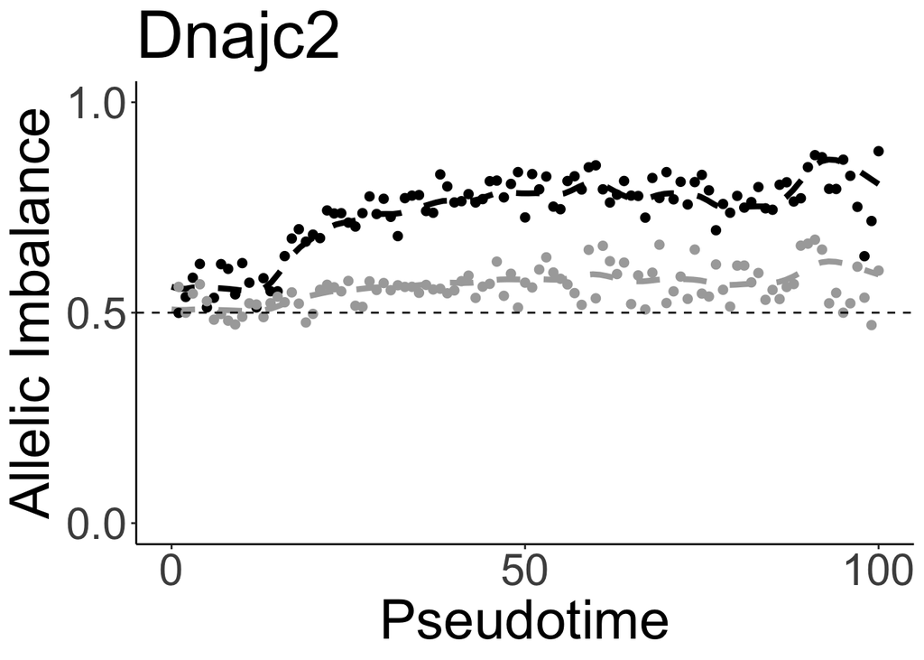

```r
plot_cis_trans_gene_mean <- function(gene){

  rev_logit <- function(x){
  1 / (1 + exp(-x))
  }

  asd <- gp_results[[gene]]

  for_plotting <- lapply(1:length(asd[[5]][[2]]), function(i){
    xx = asd[[5]][[2]][[i]]
    xx = data.frame(do.call("cbind", xx))
    xx$Sample = i
    xx$X3 <- sqrt(xx$X3)
    xx})

  for_plotting_merged <- do.call("rbind", for_plotting)
  for_plotting_merged$Sample <- as.factor(for_plotting_merged$Sample)
  for_plotting_merged$mean <- for_plotting_merged$X2

  data_plot <- data.frame(
    "F0_P" = data_f0_b6[gene, ],
    "F0_M" = data_f0_cast[gene, ],
    "F1_P" = data_f1_b6[gene, ],
    "F1_M" = data_f1_cast[gene, ]
  )

  norm_factors <- c(sum(colSums(data_f0_b6)),
                    sum(colSums(data_f0_cast)))
  norm_factors <- norm_factors / norm_factors[[1]]

  data_plot[,1:2] <- data.frame(t(t(data_plot[,1:2]) / norm_factors))
  data_plot$Interval <- 1:nrow(data_plot)
  for_plotting_merged$Sample <- ifelse(for_plotting_merged$Sample == 1, "F0", "F1")

  ggplot(for_plotting_merged, aes(X1, y = rev_logit(X2), col = Sample)) +
    geom_line(linetype = "dashed", size = 1.5) +
    scale_color_manual(values = c("F0" = "black", "F1" = "darkgrey")) +
    # geom_ribbon(aes(ymin = rev_logit(error_lower), ymax = rev_logit(error_upper), fill = Sample),
    #             alpha = 0.2) +
    theme(legend.position="top") +
    geom_point(data = data_plot, aes(Interval, (F0_P) / (F0_M + F0_P)), col = "black", size = 2) +
    geom_point(data = data_plot, aes(Interval, (F1_P) / (F1_M + F1_P)), col = "darkgrey", size = 2) +
    xlim(0, 100) + scale_fill_manual(values = c("red", "darkgrey")) + ylim(c(0, 1)) + xlab("Pseudotime") +
    ylab("Allelic Imbalance") + theme_classic() + ggtitle(gene) +
    geom_hline(yintercept = 0.5, linetype = "dashed") +
    theme(text = element_text(size = 30), legend.position = "None") +
    scale_x_continuous(breaks = c(0, 50, 100)) +
    scale_y_continuous(breaks = c(0, 0.5, 1), limits = c(0, 1))
}

plot_cis_trans_gene_mean("Dnajc2")
```

```r
gp_results$Dnajc2[[5]][[4]] - gp_results$Dnajc2[[4]][[4]] # high log-likelihood ratio compared to persistent only model
```

```
## [1] 42.58957
```

Meanwhile, genes like Ddt, which show strong dynamic cis-effects, do not show evidence for trans-effects

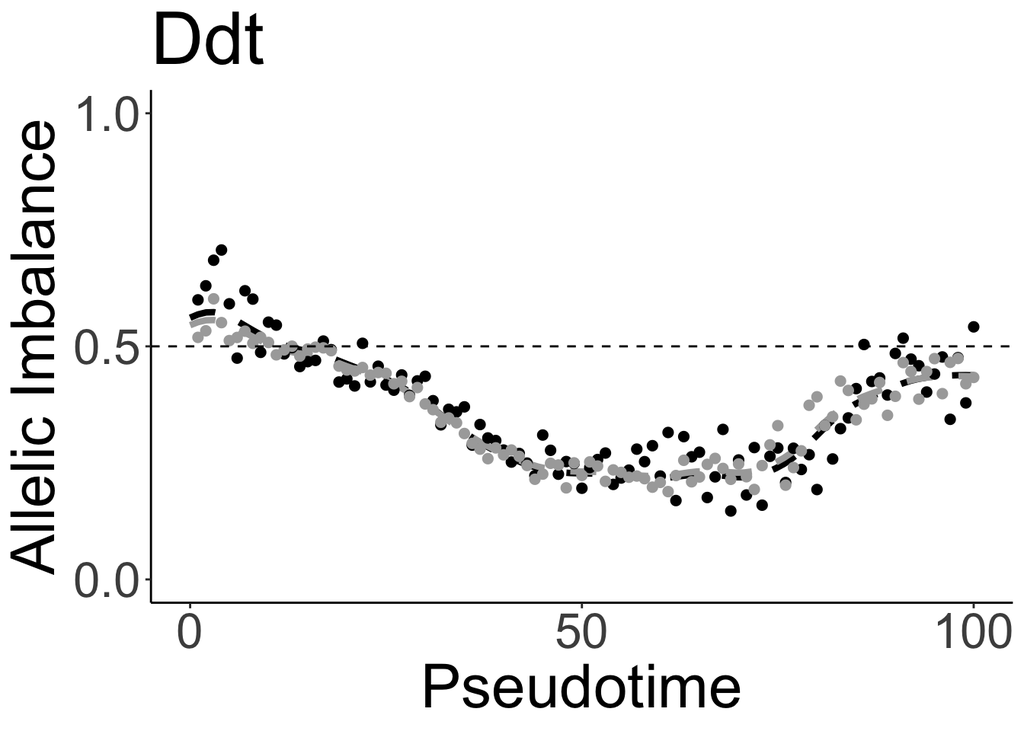

```r
plot_cis_trans_gene_mean("Ddt")
```

```r
gp_results$Ddt[[5]][[4]] - gp_results$Ddt[[4]][[4]] # both models fit equally well
```

```
## [1] -0.4489531
```